# TODO: Title

## Hyperparameter Tuning

**TODO:** This is the part where you will finetune a pretrained model with hyperparameter tuning. Remember that you have to tune a minimum of two hyperparameters. However you are encouraged to tune more. You are also encouraged to explain why you chose to tune those particular hyperparameters and the ranges.

**Note:** You will need to use the `hpo.py` script to perform hyperparameter tuning.

```python
#TODO: Declare your HP ranges, metrics etc.
from sagemaker.tuner import (
    IntegerParameter,
    CategoricalParameter,
    ContinuousParameter,
    HyperparameterTuner,
)
from sagemaker.pytorch import PyTorch

role = sagemaker.get_execution_role()

hyperparameter_ranges = {
    "lr": ContinuousParameter(0.001, 0.1),
    "batch-size": CategoricalParameter([32, 64, 128, 256, 512]),
    "epochs": IntegerParameter(1, 100),
}

objective_metric_name = "average test loss"
objective_type = "Minimize"
metric_definitions = [{"Name": "average test loss", "Regex": "average test loss: ([0-9\\.]+)"}]
```

```python
#TODO: Create estimators for your HPs
estimator = PyTorch(
    entry_point="hpo.py",
    role=role,
    py_version='py36',
    framework_version="1.8",
    instance_count=1,
    instance_type="ml.g4dn.4xlarge"
)# TODO: Your estimator here

tuner = HyperparameterTuner(
    estimator,
    objective_metric_name,
    hyperparameter_ranges,
    metric_definitions,
    max_jobs=10,
    max_parallel_jobs=2,
    objective_type=objective_type,
)# TODO: Your HP tuner here
```

```python
# TODO: Fit your HP Tuner
os.environ["SM_CHANNEL_TRAINING"] = "s3://"+ bucket_name+ "/dataset/"
os.environ['SM_MODEL_DIR']="s3://"+ bucket_name+ "/model/" # where model will be stored
tuner.fit({"training": "s3://"+ bucket_name+ "/dataset/"}, wait=False) # TODO: Remember to include your data channels
```

```
INFO:sagemaker.image_uris:Defaulting to the only supported framework/algorithm version: latest.
INFO:sagemaker.image_uris:Ignoring unnecessary instance type: None.
INFO:sagemaker:Creating hyperparameter tuning job with name: pytorch-training-230314-1048
```

```python
tuner.best_training_job()
```

```
'pytorch-training-230314-1048-009-c801f52e'
```

```python
# TODO: Get the best estimators and the best HPs

best_estimator = tuner.best_estimator()#TODO

#Get the hyperparameters of the best trained model
best_estimator.hyperparameters()
```

```
2023-03-14 11:39:49 Starting - Found matching resource for reuse
2023-03-14 11:39:49 Downloading - Downloading input data
2023-03-14 11:39:49 Training - Training image download completed. Training in progress.
2023-03-14 11:39:49 Uploading - Uploading generated training model
2023-03-14 11:39:49 Completed - Resource retained for reuse
```

```
{'_tuning_objective_metric': '"average test loss"',
 'batch-size': '"64"',
 'epochs': '1',
 'lr': '0.001126550316150208',
 'sagemaker_container_log_level': '20',
 'sagemaker_estimator_class_name': '"PyTorch"',
 'sagemaker_estimator_module': '"sagemaker.pytorch.estimator"',
 'sagemaker_job_name': '"pytorch-training-2023-03-14-10-48-42-600"',
 'sagemaker_program': '"hpo.py"',
 'sagemaker_region': '"us-east-1"',
 'sagemaker_submit_directory': '"s3://sagemaker-us-east-1-041360578609/pytorch-training-2023-03-14-10-48-42-600/source/sourcedir.tar.gz"'}
```

## Model Profiling and Debugging

TODO: Using the best hyperparameters, create and finetune a new model

**Note:** You will need to use the `train_model.py` script to perform model profiling and debugging.

```python
hyperparameter_values = {
    'batch-size': 64,
    'epochs': 1,
    'lr': 0.001126550316150208
}
```

```python
# TODO: Set up debugging and profiling rules and hooks
from sagemaker.debugger import Rule, ProfilerRule, rule_configs

rules = [
    Rule.sagemaker(rule_configs.vanishing_gradient()),
    Rule.sagemaker(rule_configs.overfit()),
    Rule.sagemaker(rule_configs.overtraining()),
    Rule.sagemaker(rule_configs.poor_weight_initialization()),
    ProfilerRule.sagemaker(rule_configs.ProfilerReport()),
]
```

```python
from sagemaker.debugger import ProfilerConfig, FrameworkProfile
from sagemaker.debugger import DebuggerHookConfig, ProfilerConfig, FrameworkProfile

debugger_config = DebuggerHookConfig(
    hook_parameters={
        "train.save_interval": "1",
        "eval.save_interval": "1"
    }
)

profiler_config = ProfilerConfig(
    system_monitor_interval_millis=500, framework_profile_params=FrameworkProfile(num_steps=1)
)
```

```python
# TODO: Create and fit an estimator
import sagemaker
from sagemaker.pytorch import PyTorch

#define the estimator
estimator = PyTorch(
    role=sagemaker.get_execution_role(),
    instance_count=1,
    instance_type="ml.g4dn.4xlarge",
    entry_point="train_model.py",
    framework_version="1.8",
    py_version='py36',
    hyperparameters=hyperparameter_values,
    profiler_config=profiler_config,
    debugger_hook_config=debugger_config,
    rules=rules,
)

os.environ["SM_CHANNEL_TRAINING"] = "s3://"+ bucket_name+ "/dataset/"
# model storing s3 bucket location
os.environ['SM_MODEL_DIR']="s3://"+ bucket_name+ "/model_train/"
estimator.fit({"training": "s3://"+ bucket_name+ "/dataset/"}, wait=False)
job_name = estimator._current_job_name
print('Job name:', job_name)
debug_artifacts_path = estimator.latest_job_debugger_artifacts_path()
print('Debug artifacts path', debug_artifacts_path)
```

[output not shown]

```
Job name: pytorch-training-2023-03-14-11-44-00-942
Debug artifacts path s3://sagemaker-us-east-1-041360578609/pytorch-training-2023-03-14-11-44-00-942/debug-output
```

```python
import boto3
session = boto3.session.Session()
region = session.region_name

if not job_name:
    job_name = "pytorch-training-2023-03-14-11-44-00-942"
estimator = sagemaker.estimator.Estimator.attach(job_name)

training_job_name = estimator.latest_training_job.name
print(f"Training jobname: {training_job_name}")
print(f"Region: {region}")
```

```
2023-03-14 11:55:34 Starting - Preparing the instances for training
2023-03-14 11:55:34 Downloading - Downloading input data
2023-03-14 11:55:34 Training - Training image download completed. Training in progress.
2023-03-14 11:55:34 Uploading - Uploading generated training model
2023-03-14 11:55:34 Completed - Training job completed
Training jobname: pytorch-training-2023-03-14-11-44-00-942
Region: us-east-1
```

```python
from smdebug.profiler.analysis.notebook_utils.training_job import TrainingJob

training_job = TrainingJob(training_job_name, region)
training_job.wait_for_sys_profiling_data_to_be_available()
```

```
ProfilerConfig:{'S3OutputPath': 's3://sagemaker-us-east-1-041360578609/', 'ProfilingIntervalInMilliseconds': 500, 'ProfilingParameters': {'DataloaderProfilingConfig': '{"StartStep": 0, "NumSteps": 1, "MetricsRegex": ".*", }', 'DetailedProfilingConfig': '{"StartStep": 0, "NumSteps": 1, }', 'FileOpenF…
s3 path:s3://sagemaker-us-east-1-041360578609/pytorch-training-2023-03-14-11-44-00-942/profiler-output


Profiler data from system is available
```

```python
# TODO: Plot a debugging output.
from smdebug.profiler.analysis.notebook_utils.timeline_charts import TimelineCharts

system_metrics_reader = training_job.get_systems_metrics_reader()
system_metrics_reader.refresh_event_file_list()

view_timeline_charts = TimelineCharts(
    system_metrics_reader,
    framework_metrics_reader=None,
    select_dimensions=["CPU", "GPU"],
    select_events=["total"],
)
```

```
select events:['total']
select dimensions:['CPU', 'GPU']
filtered_events:{'total'}
filtered_dimensions:{'GPUUtilization-nodeid:algo-1', 'CPUUtilization-nodeid:algo-1', 'GPUMemoryUtilization-nodeid:algo-1'}
```

[interactive chart not shown]

```python
job_name = estimator.latest_training_job.name
client = estimator.sagemaker_session.sagemaker_client
description = client.describe_training_job(TrainingJobName=estimator.latest_training_job.name)
```

```python
import time
from IPython import display

%matplotlib inline

while description["SecondaryStatus"] not in {"Stopped", "Completed", "Failed"}:
    description = client.describe_training_job(TrainingJobName=job_name)
    primary_status = description["TrainingJobStatus"]
    secondary_status = description["SecondaryStatus"]
    print("====================================================================")
    print("TrainingJobStatus: ", primary_status, " | SecondaryStatus: ", secondary_status)
    print("====================================================================")
    for r in range(len(estimator.latest_training_job.rule_job_summary())):
        rule_summary = estimator.latest_training_job.rule_job_summary()
        print(
            rule_summary[r]["RuleConfigurationName"], ": ", rule_summary[r]["RuleEvaluationStatus"]
        )
        if rule_summary[r]["RuleEvaluationStatus"] == "IssuesFound":
            print(rule_summary[r]["StatusDetails"])
        print("====================================================================")
    print("Current time: ", time.asctime())
    display.clear_output(wait=True)
    time.sleep(10) # in seconds
```

```python
# Check Training Performance
from smdebug.trials import create_trial
from smdebug.core.modes import ModeKeys

if not debug_artifacts_path:
    debug_artifacts_path = "s3://sagemaker-us-east-1-600041687030/pytorch-training-2023-03-14-11-44-00-942/debug-output"

trial = create_trial(debug_artifacts_path)
```

```
[2023-03-14 12:20:12.866 1-8-1-cpu-py36-ml-t3-medium-05a4a7868130c7575335c53b16c7:34 INFO s3_trial.py:42] Loading trial debug-output at path s3://sagemaker-us-east-1-041360578609/pytorch-training-2023-03-14-11-44-00-942/debug-output
[2023-03-14 12:20:13.240 1-8-1-cpu-py36-ml-t3-medium-05a4a7868130c7575335c53b16c7:34 WARNING s3handler.py:183] Encountered the exception An error occurred while reading from response stream: ('Connection broken: IncompleteRead(0 bytes read, 4782 more expected)', IncompleteRead(0 bytes read, 4782 mor…
```

```python
trial.tensor_names()
```

```
[2023-03-14 12:20:28.146 1-8-1-cpu-py36-ml-t3-medium-05a4a7868130c7575335c53b16c7:34 INFO trial.py:198] Training has ended, will refresh one final time in 1 sec.
[2023-03-14 12:20:29.166 1-8-1-cpu-py36-ml-t3-medium-05a4a7868130c7575335c53b16c7:34 INFO trial.py:210] Loaded all steps
```

```
['CrossEntropyLoss_output_0',
 'gradient/ResNet_fc.0.bias',
 'gradient/ResNet_fc.0.weight',
 'gradient/ResNet_fc.2.bias',
 'gradient/ResNet_fc.2.weight',
 'layer1.0.relu_input_0',
 'layer1.0.relu_input_1',
 'layer1.0.relu_input_2',
 'layer1.1.relu_input_0',
 'layer1.1.relu_input_1',
 'layer1.1.relu_input_2',
 'layer1.2.relu_input_0',
 'layer1.2.relu_input_1',
 'layer1.2.relu_input_2',
 'layer2.0.relu_input_0',
 'layer2.0.relu_input_1',
 'layer2.0.relu_input_2',
 'layer2.1.relu_input_0',
 'layer2.1.relu_input_1',
 'layer2.1.relu_input_2',
 'layer2.2.relu_input_0',
 'layer2.2.relu_input_1',
 'layer2.2.relu_input_2',
 'layer2.3.relu_input_0',
 'layer2.3.relu_input_1',
 'layer2.3.relu_input_2',
 'layer3.0.relu_input_0',
 'layer3.0.relu_input_1',
 'layer3.0.relu_input_2',
 'layer3.1.relu_input_0',
 'layer3.1.relu_input_1',
 'layer3.1.relu_input_2',
 'layer3.2.relu_input_0',
 'layer3.2.relu_input_1',
 'layer3.2.relu_input_2',
 'layer3.3.relu_input_0',
 'layer3.3.relu_input_1',
 'layer3.3.relu_input_2',
 'layer3.4.relu_input_0',
 'layer3.4.relu_input_1',
 'layer3.4.relu_input_2',
 'layer3.5.relu_input_0',
 'layer3.5.relu_input_1',
 'layer3.5.relu_input_2',
 'layer4.0.relu_input_0',
 'layer4.0.relu_input_1',
 'layer4.0.relu_input_2',
 'layer4.1.relu_input_0',
 'layer4.1.relu_input_1',
 'layer4.1.relu_input_2',
 'layer4.2.relu_input_0',
 'layer4.2.relu_input_1',
 'layer4.2.relu_input_2',
 'relu_input_0']
```

```python
len(trial.tensor("CrossEntropyLoss_output_0").steps(mode=ModeKeys.TRAIN))
```

```
315
```

```python
len(trial.tensor("CrossEntropyLoss_output_0").steps(mode=ModeKeys.EVAL))
```

```
56
```

```python
def get_data(trial, tname, mode):
    tensor = trial.tensor(tname)
    steps = tensor.steps(mode=mode)
    vals = []
    for s in steps:
        vals.append(tensor.value(s, mode=mode))
    return steps, vals
```

```python
import matplotlib.pyplot as plt
from mpl_toolkits.axes_grid1 import host_subplot

def plot_tensor(trial, tensor_name):

    steps_train, vals_train = get_data(trial, tensor_name, mode=ModeKeys.TRAIN)
    print("loaded TRAIN data")
    steps_eval, vals_eval = get_data(trial, tensor_name, mode=ModeKeys.EVAL)
    print("loaded EVAL data")

    fig = plt.figure(figsize=(10, 7))
    host = host_subplot(111)

    par = host.twiny()

    host.set_xlabel("TRAIN PHASE")
    par.set_xlabel("EVALUATION PHASE")
    host.set_ylabel(tensor_name)

    (p1,) = host.plot(steps_train, vals_train, label=tensor_name)
    print("TRAIN Plot Completed")
    (p2,) = par.plot(steps_eval, vals_eval, label="val_" + tensor_name)
    print("EVALUATION Plot Completed")
    leg = plt.legend()

    host.xaxis.get_label().set_color(p1.get_color())
    leg.texts[0].set_color(p1.get_color())

    par.xaxis.get_label().set_color(p2.get_color())
    leg.texts[1].set_color(p2.get_color())

    plt.ylabel(tensor_name)

    plt.show()
    fig.savefig('training_debug_values.png')
```

```
loaded TRAIN data
loaded EVAL data
TRAIN Plot Completed
EVALUATION Plot Completed
```

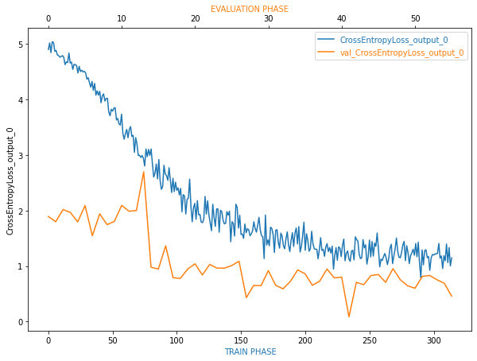

```python
plot_tensor(trial, "CrossEntropyLoss_output_0")
```

**TODO**: Is there some anomalous behaviour in your debugging output? If so, what is the error and how will you fix it?  
**TODO**: If not, suppose there was an error. What would that error look like and how would you have fixed it? When there is steady crossentropy falls in training data we should train the model with more epochs to get better results.

```python
#Display the profiler output
rule_output_path = estimator.output_path + estimator.latest_training_job.job_name + "/rule-output"
print(f"The profiler report in {rule_output_path}")
```

```
The profiler report in s3://sagemaker-us-east-1-041360578609/pytorch-training-2023-03-14-11-44-00-942/rule-output
```

```python
! aws s3 ls {rule_output_path} --recursive
```

```
2023-03-14 11:55:08     416548 pytorch-training-2023-03-14-11-44-00-942/rule-output/ProfilerReport/profiler-output/profiler-report.html
2023-03-14 11:55:08     271188 pytorch-training-2023-03-14-11-44-00-942/rule-output/ProfilerReport/profiler-output/profiler-report.ipynb
2023-03-14 11:55:03        192 pytorch-training-2023-03-14-11-44-00-942/rule-output/ProfilerReport/profiler-output/profiler-reports/BatchSize.json
2023-03-14 11:55:03      14801 pytorch-training-2023-03-14-11-44-00-942/rule-output/ProfilerReport/profiler-output/profiler-reports/CPUBottleneck.json
2023-03-14 11:55:03       2563 pytorch-training-2023-03-14-11-44-00-942/rule-output/ProfilerReport/profiler-output/profiler-reports/Dataloader.json
2023-03-14 11:55:03        336 pytorch-training-2023-03-14-11-44-00-942/rule-output/ProfilerReport/profiler-output/profiler-reports/GPUMemoryIncrease.json
2023-03-14 11:55:03       2312 pytorch-training-2023-03-14-11-44-00-942/rule-output/ProfilerReport/profiler-output/profiler-reports/IOBottleneck.json
2023-03-14 11:55:03        312 pytorch-training-2023-03-14-11-44-00-942/rule-output/ProfilerReport/profiler-output/profiler-reports/LoadBalancing.json
2023-03-14 11:55:03        334 pytorch-training-2023-03-14-11-44-00-942/rule-output/ProfilerReport/profiler-output/profiler-reports/LowGPUUtilization.json
2023-03-14 11:55:03        232 pytorch-training-2023-03-14-11-44-00-942/rule-output/ProfilerReport/profiler-output/profiler-reports/MaxInitializationTime.json
2023-03-14 11:55:03       1835 pytorch-training-2023-03-14-11-44-00-942/rule-output/ProfilerReport/profiler-output/profiler-reports/OverallFrameworkMetrics.json
2023-03-14 11:55:03        611 pytorch-training-2023-03-14-11-44-00-942/rule-output/ProfilerReport/profiler-output/profiler-reports/OverallSystemUsage.json
2023-03-14 11:55:03       2199 pytorch-training-2023-03-14-11-44-00-942/rule-output/ProfilerReport/profiler-output/profiler-reports/StepOutlier.json
```

```python
! aws s3 cp {rule_output_path} ./ --recursive
```

[output not shown]

```python
import os, IPython
# get the autogenerated folder name of profiler report
profiler_report_name = [rule["RuleConfigurationName"] for rule in estimator.latest_training_job.rule_job_summary()
                        if "Profiler" in rule["RuleConfigurationName"]
                       ][0]

print(profiler_report_name)
IPython.display.HTML(filename=profiler_report_name + "/profiler-output/profiler-report.html")
```

```
ProfilerReport
```

SageMaker Debugger Profiling Report

SageMaker Debugger auto generated this report. You can generate similar reports on all supported training jobs. The report provides summary of training job, system resource usage statistics, framework metrics, rules summary, and detailed analysis from each rule. The graphs and tables are interactive.

**Legal disclaimer:** This report and any recommendations are provided for informational purposes only and are not definitive. You are responsible for making your own independent assessment of the information.

```
# Parameters
processing_job_arn = "arn:aws:sagemaker:us-east-1:041360578609:processing-job/pytorch-training-2023-03-1-profilerreport-94c120e1"
```

Training job summary

[interactive chart not shown]

System usage statistics

[interactive chart not shown]

Framework metrics summary

[interactive chart not shown]

Overview: CPU operators

[interactive chart not shown]

Overview: GPU operators

[interactive chart not shown]

Rules summary

The following table shows a profiling summary of the Debugger built-in rules. The table is sorted by the rules that triggered the most frequently. During your training job, the GPUMemoryIncrease rule was the most frequently triggered. It processed 1065 datapoints and was triggered 8 times.

|  | Description | Recommendation | Number of times rule triggered | Number of datapoints | Rule parameters |
| --- | --- | --- | --- | --- | --- |
| GPUMemoryIncrease | Measures the average GPU memory footprint and triggers if there is a large increase. | Choose a larger instance type with more memory if footprint is close to maximum available memory. | 8 | 1065 | increase:5 patience:1000 window:10 |
| LowGPUUtilization | Checks if the GPU utilization is low or fluctuating. This can happen due to bottlenecks, blocking calls for synchronizations, or a small batch size. | Check if there are bottlenecks, minimize blocking calls, change distributed training strategy, or increase the batch size. | 1 | 1065 | threshold_p95:70 threshold_p5:10 window:500 patience:1000 |
| BatchSize | Checks if GPUs are underutilized because the batch size is too small. To detect this problem, the rule analyzes the average GPU memory footprint, the CPU and the GPU utilization. | The batch size is too small, and GPUs are underutilized. Consider running on a smaller instance type or increasing the batch size. | 0 | 1064 | cpu_threshold_p95:70 gpu_threshold_p95:70 gpu_memory_threshold_p95:70 patience:1000 window:500 |
| MaxInitializationTime | Checks if the time spent on initialization exceeds a threshold percent of the total training time. The rule waits until the first step of training loop starts. The initialization can take longer if do… | Initialization takes too long. If using File mode, consider switching to Pipe mode in case you are using TensorFlow framework. | 0 | 318 | threshold:20 |
| LoadBalancing | Detects workload balancing issues across GPUs. Workload imbalance can occur in training jobs with data parallelism. The gradients are accumulated on a primary GPU, and this GPU might be overused with … | Choose a different distributed training strategy or a different distributed training framework. | 0 | 1065 | threshold:0.2 patience:1000 |
| CPUBottleneck | Checks if the CPU utilization is high and the GPU utilization is low. It might indicate CPU bottlenecks, where the GPUs are waiting for data to arrive from the CPUs. The rule evaluates the CPU and GPU… | Consider increasing the number of data loaders or applying data pre-fetching. | 0 | 1066 | threshold:50 cpu_threshold:90 gpu_threshold:10 patience:1000 |
| IOBottleneck | Checks if the data I/O wait time is high and the GPU utilization is low. It might indicate IO bottlenecks where GPU is waiting for data to arrive from storage. The rule evaluates the I/O and GPU utili… | Pre-fetch data or choose different file formats, such as binary formats that improve I/O performance. | 0 | 1066 | threshold:50 io_threshold:50 gpu_threshold:10 patience:1000 |
| Dataloader | Checks how many data loaders are running in parallel and whether the total number is equal the number of available CPU cores. The rule triggers if number is much smaller or larger than the number of a… | Change the number of data loader processes. | 0 | 1 | min_threshold:70 max_threshold:200 |
| StepOutlier | Detects outliers in step duration. The step duration for forward and backward pass should be roughly the same throughout the training. If there are significant outliers, it may indicate a system stall… | Check if there are any bottlenecks (CPU, I/O) correlated to the step outliers. | 0 | 318 | threshold:3 mode:None n_outliers:10 stddev:3 |

Analyzing the training loop

Step duration analysis

[interactive chart not shown]

**Step durations on node algo-1-27:**

The following table is a summary of the statistics of step durations measured on node algo-1-27. The rule has analyzed the step duration from Step:ModeKeys.TRAIN phase. The average step duration on node algo-1-27 was 0.07s. The rule detected 1 outliers, where step duration was larger than 3 times the standard deviation of 0.65s

|  | mean | max | p99 | p95 | p50 | min |
| --- | --- | --- | --- | --- | --- | --- |
| Step Durations in [s] | 0.07 | 10.96 | 0.03 | 0.03 | 0.03 | 0.03 |

The following histogram shows the step durations measured on the different nodes. You can turn on or turn off the visualization of histograms by selecting or unselecting the labels in the legend.

[interactive chart not shown]

GPU utilization analysis

**Usage per GPU**

[interactive chart not shown]

**GPU utilization of gpu0 on node algo-1:**

[interactive chart not shown]

**Workload balancing**

[interactive chart not shown]

Dataloading analysis

[interactive chart not shown]

Batch size

[interactive chart not shown]

CPU bottlenecks

[interactive chart not shown]

I/O bottlenecks

[interactive chart not shown]

GPU memory

[interactive chart not shown]

**Memory utilization of gpu0 on node algo-1:**

[interactive chart not shown]

[figure not shown]

## Model Deploying

```python
from sagemaker.predictor import Predictor
jpeg_serializer = sagemaker.serializers.IdentitySerializer("image/jpeg")
json_deserializer = sagemaker.deserializers.JSONDeserializer()

class ImagePredictor(Predictor):
    def __init__(self, endpoint_name, sagemaker_session):
        super(ImagePredictor, self).__init__(
            endpoint_name,
            sagemaker_session=sagemaker_session,
            serializer=jpeg_serializer,
            deserializer=json_deserializer
        )
```

```python
model_location=estimator.model_data
# model_location = "s3://sagemaker-us-east-1-071394031625/pytorch-training-2022-04-13-23-57-46-790/output/model.tar.gz"
print(model_location)
```

```
s3://sagemaker-us-east-1-041360578609/pytorch-training-2023-03-14-11-44-00-942/output/model.tar.gz
```

```python
from sagemaker.pytorch import PyTorchModel
pytorch_model = PyTorchModel(model_data=model_location,
                             role=role,
                             entry_point='inference.py',
                             py_version='py36',
                             framework_version='1.8',
                             predictor_cls=ImagePredictor)
```

```python
# Deploy the model to an endpoint

predictor = pytorch_model.deploy(initial_instance_count=1, instance_type='ml.g4dn.4xlarge') # TODO: Add your deployment configuration like instance type and number of instances
```

```
INFO:sagemaker:Creating model with name: pytorch-inference-2023-03-14-12-13-56-853
INFO:sagemaker:Creating endpoint with name pytorch-inference-2023-03-14-12-13-57-583
```

```
----------!
```

```python
with open("Akita_00276.jpg", "rb") as image:
    f = image.read()
    img_bytes = bytearray(f)

type(img_bytes)
```

```
bytearray
```

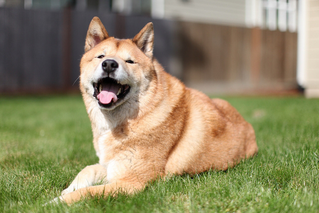

```python
from PIL import Image
import io
Image.open(io.BytesIO(img_bytes))
```

```python
# TODO: Run an prediction on the endpoint
response=predictor.predict(img_bytes, initial_args={"ContentType": "image/jpeg"})
```

```python
print("Raw prediction result:")
print(response)
print()

labeled_predictions = list(zip(range(133), response[0]))
print("Labeled predictions: ")
print(labeled_predictions)
print()

labeled_predictions.sort(key=lambda label_and_prob: 1.0 - label_and_prob[1])
print("Most likely answer: {}".format(labeled_predictions[0]))
```

```
Raw prediction result:
[[-10.75078296661377, -5.996554374694824, -6.2834930419921875, 5.454801082611084, -0.06917239725589752, -4.932031631469727, -2.7603302001953125, -0.19303655624389648, -6.4962663650512695, 2.7335691452026367, -0.7907075881958008, -5.57733154296875, -4.064122200012207, -1.2908878326416016, -5.60432624…

Labeled predictions:
[(0, -10.75078296661377), (1, -5.996554374694824), (2, -6.2834930419921875), (3, 5.454801082611084), (4, -0.06917239725589752), (5, -4.932031631469727), (6, -2.7603302001953125), (7, -0.19303655624389648), (8, -6.4962663650512695), (9, 2.7335691452026367), (10, -0.7907075881958008), (11, -5.57733154…

Most likely answer: (3, 5.454801082611084)
```

```python
# shutdown/delete endpoint
predictor.delete_endpoint()
```

```
INFO:sagemaker:Deleting endpoint configuration with name: pytorch-inference-2023-03-14-12-13-57-583
INFO:sagemaker:Deleting endpoint with name: pytorch-inference-2023-03-14-12-13-57-583
```